# Introduction to Statistics for Data Scientists

# Regression Examples

```r
require(ggplot2)
require(qdata)
```

## Example: Depressant drug and rats regression

### Data description

In an experiment to investigate the effects of a depressant drug, the reaction times of ten male rats to a certain stimulus were measured after a specified dose of the drug have been administered to each rat.

### Data loading

```r
data(drug)
str(drug)
```

```
## Classes 'tbl_df', 'tbl' and 'data.frame':    10 obs. of  3 variables:
##  $ rat : int  1 2 3 4 5 6 7 8 9 10
##  $ dose: num  0 0.1 0.2 0.3 0.4 0.5 0.6 0.7 0.8 0.9
##  $ time: num  0.32 0.24 0.4 0.52 0.44 0.56 0.64 0.52 0.6 0.8
```

```r
head(drug)
```

```
##   rat dose time
## 1   1  0.0 0.32
## 2   2  0.1 0.24
## 3   3  0.2 0.40
## 4   4  0.3 0.52
## 5   5  0.4 0.44
## 6   6  0.5 0.56
```

### Descriptives

Since we are mainly interested in relation between `dose` of drug and reaction `time`, we start the descriptive analysis plotting a graph that relates the two variables.

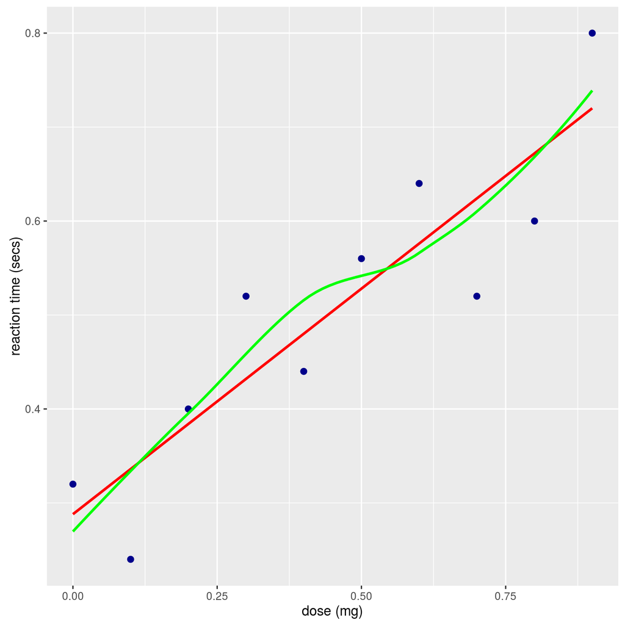

Scatterplot of time Vs. dose with fitted linear regression and loess line

```r
ggp <- ggplot(data=drug, mapping = aes(x=dose, y=time)) +
  geom_point(color="darkblue", size=2) +
  geom_smooth(method = "lm", colour="red", se = FALSE) +
  geom_smooth(method = "loess", colour="green", se = FALSE, span=1) +
  xlab("dose (mg)") + ylab("reaction time (secs)")
print(ggp)
```

In above code, `method="lm"` of `geom_smooth()` function adds regression line to ggplot object and `method="loess"` of `geom_smooth()` function adds local regression line to ggplot object.

Perhaps a simple straight linear regression is a good choice to describe the relation.

### Inference and models

We then fit a simple linear model $E(y_i \vert xi) = \beta_0 + \beta_1 \cdot x_i$ between reaction time and dose of drug and we produce a summary of the fitted model.

```r
fm <- lm(time ~ dose, data = drug)
summary(fm)
```

```
##
## Call:
## lm(formula = time ~ dose, data = drug)
##
## Residuals:
##    Min     1Q Median     3Q    Max
## -0.104 -0.064  0.024  0.056  0.088
##
## Coefficients:
##             Estimate Std. Error t value Pr(>|t|)
## (Intercept)  0.28800    0.04522   6.368 0.000216 ***
## dose         0.48000    0.08471   5.666 0.000472 ***
## ---
## Signif. codes:  0 '***' 0.001 '**' 0.01 '*' 0.05 '.' 0.1 ' ' 1
##
## Residual standard error: 0.07694 on 8 degrees of freedom
## Multiple R-squared:  0.8005, Adjusted R-squared:  0.7756
## F-statistic: 32.11 on 1 and 8 DF,  p-value: 0.0004724
```

Reading the results, it appears that if we increase `dose` by one unit, `time` increases by 0.48 on average, and this growth is significant.

Another way to obtain the p-value for `dose` parameter is comparing the `time ~ dose` model with `time ~ 1` model, and testing significancy of slope via `anova()`

```r
anova(fm,update(fm,.~.-dose))
```

```
## Analysis of Variance Table
##
## Model 1: time ~ dose
## Model 2: time ~ 1
##   Res.Df     RSS Df Sum of Sq      F    Pr(>F)
## 1      8 0.04736
## 2      9 0.23744 -1  -0.19008 32.108 0.0004724 ***
## ---
## Signif. codes:  0 '***' 0.001 '**' 0.01 '*' 0.05 '.' 0.1 ' ' 1
```

The results are the same.

### Residual analysis

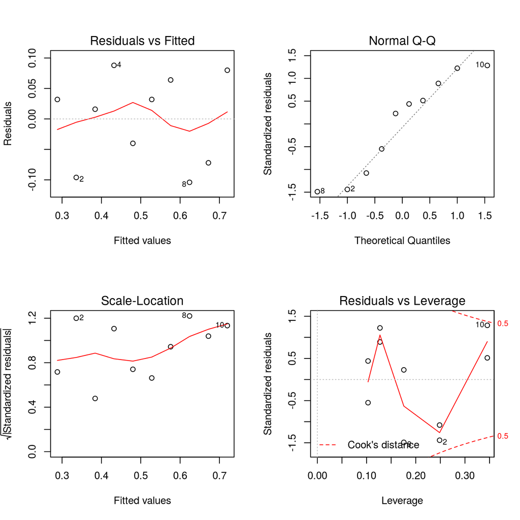

Residual plot of simple linear model

```r
op <- par(mfrow = c(2, 2))
plot(fm)
par(op)
```

Plots do not evidence particular problems.

## Example: Laboratory and on-line tools

### Data description

Two pH measurement tools are compared: one instrument is a “gold standard”, and is the “laboratory” tool, the other is an on-line (on the field) tool.  
Same samples are measured by using both instruments to see if on-line tool performs as laboratory tool.

### Data loading

```r
data(labonline)
str(labonline)
```

```
## Classes 'tbl_df', 'tbl' and 'data.frame':    20 obs. of  2 variables:
##  $ Lab   : num  8.6 8.8 9 9.1 9 9.1 9.1 9.2 9.1 9.1 ...
##  $ Online: num  8.7 8.7 9 9.1 8.9 9 9.1 9.1 9 9.1 ...
```

### Descriptives

Since in this example we are simply interested in the relation between `Lab` and `Online` tool readings, we perform the descriptive analysis with a scatterplot only.

```r
summary(labonline)
```

```
##       Lab            Online
##  Min.   :8.600   Min.   :8.700
##  1st Qu.:8.950   1st Qu.:8.875
##  Median :9.050   Median :9.000
##  Mean   :9.025   Mean   :9.005
##  3rd Qu.:9.100   3rd Qu.:9.100
##  Max.   :9.400   Max.   :9.400
```

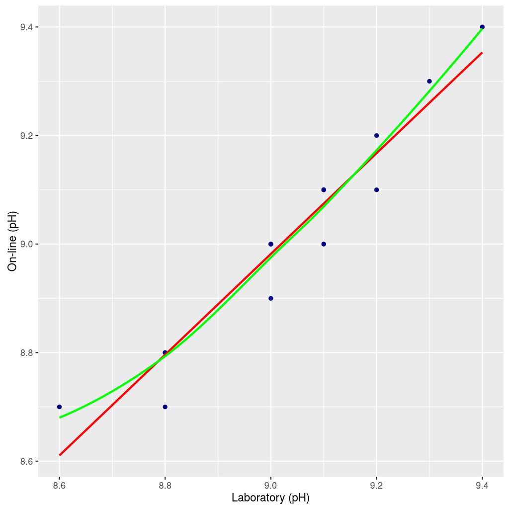

Scatterplot of Online Vs. Lab

```r
ggp <- ggplot(data=labonline, mapping = aes(x=Lab, y=Online)) +
  geom_point(color="darkblue") +
  geom_smooth(method = "lm", colour="red", se = FALSE) +
  geom_smooth(method = "loess", colour="green", se = FALSE, span=1) +
  xlab("Laboratory (pH)") + ylab("On-line (pH)")

print(ggp)
```

### Inference and models

Let us produce a summary of a simple linear model $E(y_i \vert xi) = \beta_0 + \beta_1 \cdot x_i$

```r
fm <- lm(Online ~ Lab, data = labonline)
fm1 <- summary(fm)
fm1
```

```
##
## Call:
## lm(formula = Online ~ Lab, data = labonline)
##
## Residuals:
##      Min       1Q   Median       3Q      Max
## -0.09613 -0.01396  0.01821  0.02538  0.08953
##
## Coefficients:
##             Estimate Std. Error t value Pr(>|t|)
## (Intercept)   0.6270     0.5606   1.118    0.278
## Lab           0.9283     0.0621  14.949 1.36e-11 ***
## ---
## Signif. codes:  0 '***' 0.001 '**' 0.01 '*' 0.05 '.' 0.1 ' ' 1
##
## Residual standard error: 0.05186 on 18 degrees of freedom
## Multiple R-squared:  0.9255, Adjusted R-squared:  0.9213
## F-statistic: 223.5 on 1 and 18 DF,  p-value: 1.365e-11
```

Only slope is significant.  
Intercept not significant means that when laboratory tool returns 0, on-line tool returns a mean value that can be 0.  
This behavior is correct.  
Another test to perform is to verify if the slope may be equal to 1.  
The Wald test to check this may be performed through:

```r
2*pt(abs(fm1$coefficients[2,1]-1)/fm1$coefficients[2,2],
     df=fm1$df[2],
     lower.tail=FALSE)
```

```
## [1] 0.2634497
```

Since the returned value (p-value) is greater than $\alpha$=0.05, the null hypothesis that $\beta_1$=1 is accepted.

### Residual analysis

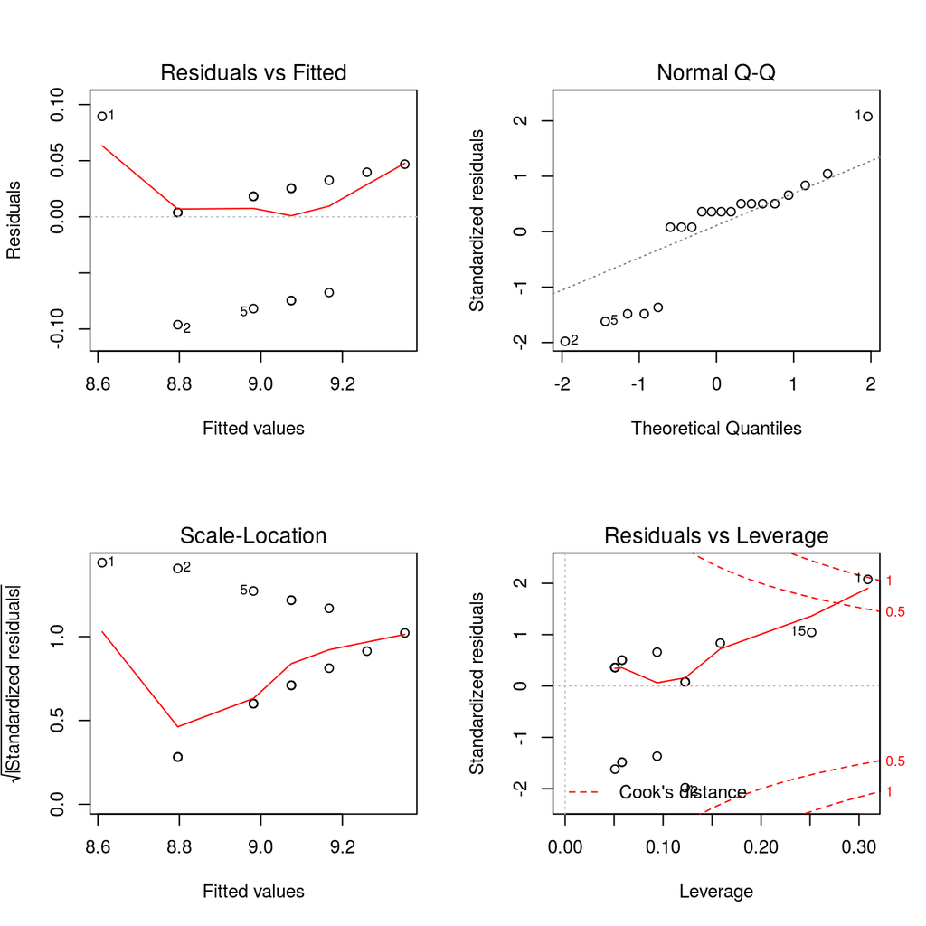

Residual plot of Online Vs. Lab model

```r
op <- par(mfrow = c(2, 2))
plot(fm)
par(op)
```

The residuals are not really “nice”, but their behavior might be due to rounding of pH values to the first decimal place only.

## Example: Polyesterification regression

### Data description

In the study of the polyesterification of fatty acids with glycols, the effect of temperature ($^◦$C) on the percentage conversion of the esterification process was investigated. Data are the results of an experiment using a catalyst of $4 \cdot 10^{−4}$ mole zinc chloride per 100 grams of fatty acid.

### Data loading

```r
data(polyester)
str(polyester)
```

```
## Classes 'tbl_df', 'tbl' and 'data.frame':    6 obs. of  2 variables:
##  $ temperature: int  175 200 225 250 275 300
##  $ conversion : int  67 83 93 97 99 92
```

```r
head(polyester)
```

```
##   temperature conversion
## 1         175         67
## 2         200         83
## 3         225         93
## 4         250         97
## 5         275         99
## 6         300         92
```

### Descriptives

Let us plot the relation between dependent and independent variables.

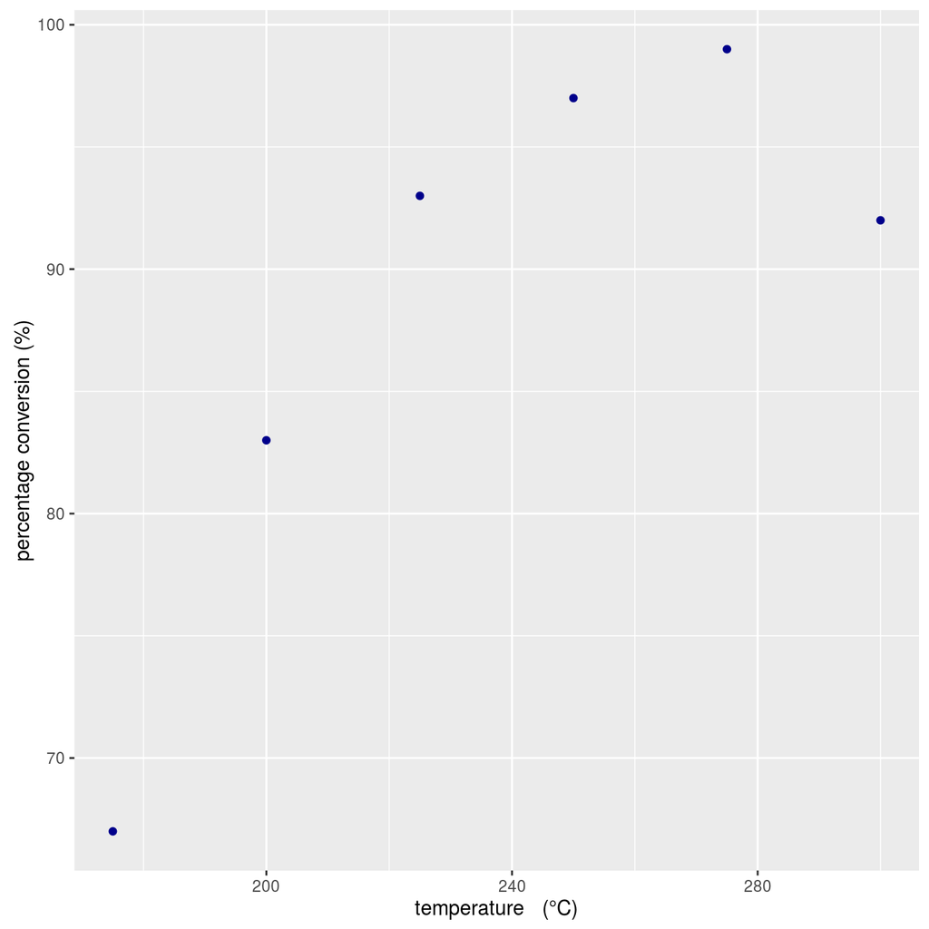

Scatterplot of conversion Vs. temperature

```r
ggp <- ggplot(data = polyester, mapping=aes(x = temperature, y=conversion)) +
  geom_point(color="darkblue") + xlab("temperature   (°C)") +
  ylab("percentage conversion (%)")

print(ggp)
```

A quadratic function seems to fit the data.

### Inference and models

Despite above results, we initially try to estimate a simple linear model, and to produce an illustrative graph of the model.

```r
fm0 <- lm(conversion ~ temperature, data = polyester)
summary(fm0)
```

```
##
## Call:
## lm(formula = conversion ~ temperature, data = polyester)
##
## Residuals:
##      1      2      3      4      5      6
## -8.857  2.086  7.029  5.971  2.914 -9.143
##
## Coefficients:
##             Estimate Std. Error t value Pr(>|t|)
## (Intercept) 40.45714   18.60031   2.175   0.0953 .
## temperature  0.20229    0.07708   2.624   0.0585 .
## ---
## Signif. codes:  0 '***' 0.001 '**' 0.01 '*' 0.05 '.' 0.1 ' ' 1
##
## Residual standard error: 8.061 on 4 degrees of freedom
## Multiple R-squared:  0.6326, Adjusted R-squared:  0.5407
## F-statistic: 6.887 on 1 and 4 DF,  p-value: 0.05853
```

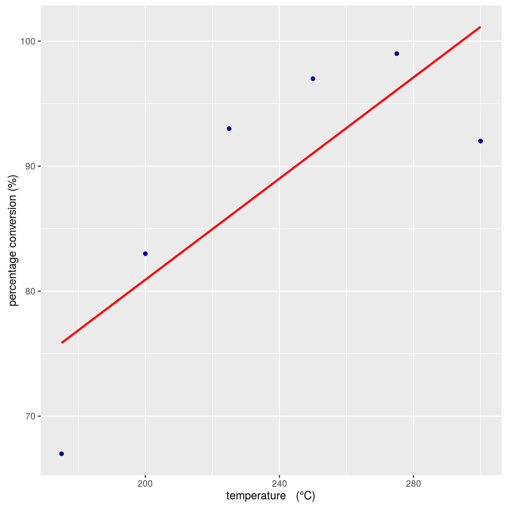

Scatterplot of conversion Vs. temperature with linear fit

```r
ggp0 <- ggp + geom_smooth(method = "lm", colour="red", se = FALSE)

print(ggp0)
```

Now the graph of residuals.

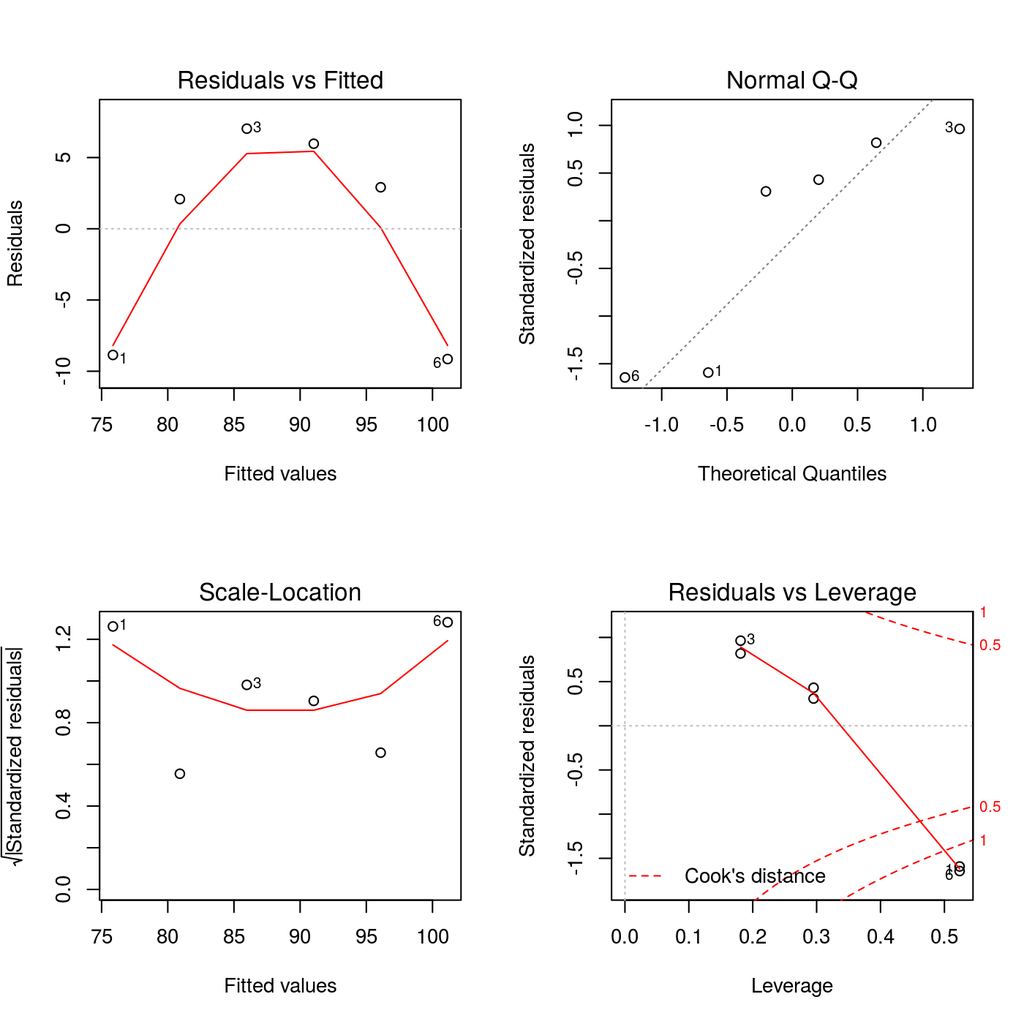

Residual analysis of simple linear model conversion Vs. temperature

```r
op <- par(mfrow=c(2,2))
plot(fm0)
par(op)
```

Either graphs suggest that a curve effect may exist.  
Another plot to check this hypothesis, is the plot of residuals Vs. independent variable:

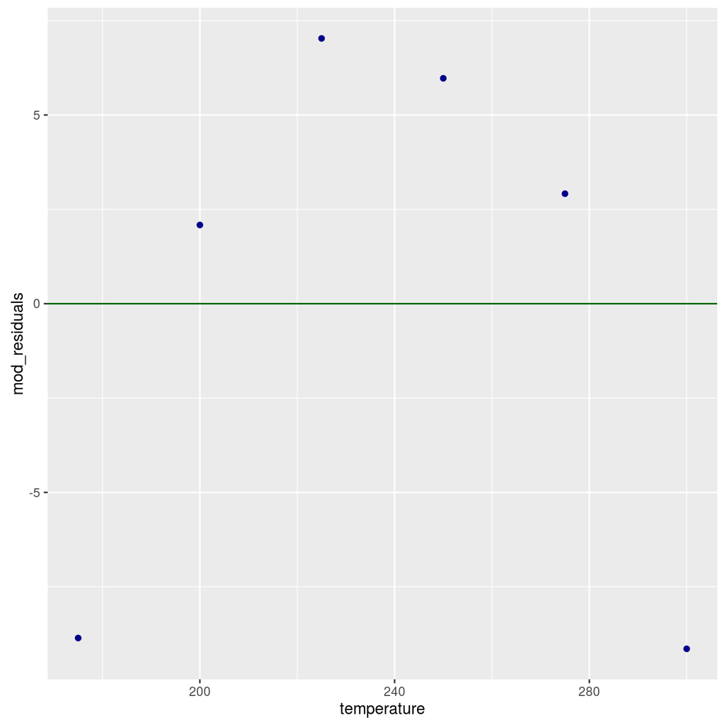

Scatterplot of residuals Vs. temperature

```r
df <- data.frame(temperature = polyester$temperature, mod_residuals =residuals(fm0))

ggp <- ggplot(data = df, mapping = aes(x=temperature, y=mod_residuals)) +
  geom_point(color="darkblue") + geom_hline(yintercept = 0, colour="darkgreen")

print(ggp)
```

A clear curvature appears.

At this point, a quadratic model can be tried:

```r
fm <- lm(conversion ~ poly(temperature, 2, raw = TRUE), data = polyester)
```

or, alternatively:

```r
fm <- update(fm0,.~. + I(temperature^2))
```

Now we see the model summaries

```r
summary(fm)
```

```
##
## Call:
## lm(formula = conversion ~ temperature + I(temperature^2), data = polyester)
##
## Residuals:
##        1        2        3        4        5        6
## -0.10714  0.33571  0.02857 -1.02857  1.16429 -0.39286
##
## Coefficients:
##                    Estimate Std. Error t value Pr(>|t|)
## (Intercept)      -1.888e+02  1.372e+01  -13.76 0.000830 ***
## temperature       2.197e+00  1.182e-01   18.59 0.000340 ***
## I(temperature^2) -4.200e-03  2.481e-04  -16.93 0.000449 ***
## ---
## Signif. codes:  0 '***' 0.001 '**' 0.01 '*' 0.05 '.' 0.1 ' ' 1
##
## Residual standard error: 0.9474 on 3 degrees of freedom
## Multiple R-squared:  0.9962, Adjusted R-squared:  0.9937
## F-statistic: 392.6 on 2 and 3 DF,  p-value: 0.0002348
```

All parameters are significant, and this confirms the initial observation of a curvilinear relation.

### Residual analysis

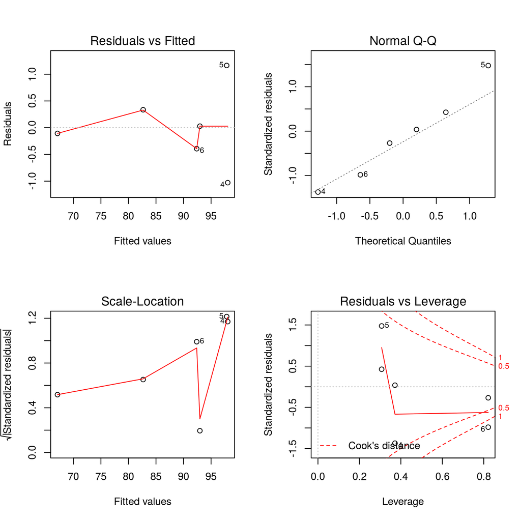

Residual plot of final model

```r
op <- par(mfrow=c(2,2))
plot(fm)
par(op)
```

The residual plots seem “regular” enough.

As an additional check, we can try also to add a term of cube of temperature.

```r
(fm1 <- update(fm,.~. + I(temperature^3)))
```

```
##
## Call:
## lm(formula = conversion ~ temperature + I(temperature^2) + I(temperature^3),
##     data = polyester)
##
## Coefficients:
##      (Intercept)       temperature  I(temperature^2)  I(temperature^3)
##       -1.663e+02         1.902e+00        -2.933e-03        -1.778e-06
```

```r
summary(fm1)
```

```
##
## Call:
## lm(formula = conversion ~ temperature + I(temperature^2) + I(temperature^3),
##     data = polyester)
##
## Residuals:
##        1        2        3        4        5        6
## -0.19048  0.45238  0.09524 -1.09524  1.04762 -0.30952
##
## Coefficients:
##                    Estimate Std. Error t value Pr(>|t|)
## (Intercept)      -1.663e+02  1.168e+02  -1.424    0.290
## temperature       1.902e+00  1.524e+00   1.248    0.338
## I(temperature^2) -2.933e-03  6.519e-03  -0.450    0.697
## I(temperature^3) -1.778e-06  9.139e-06  -0.195    0.864
##
## Residual standard error: 1.15 on 2 degrees of freedom
## Multiple R-squared:  0.9963, Adjusted R-squared:  0.9907
## F-statistic: 177.8 on 3 and 2 DF,  p-value: 0.005598
```

```r
anova(fm1,fm)
```

```
## Analysis of Variance Table
##
## Model 1: conversion ~ temperature + I(temperature^2) + I(temperature^3)
## Model 2: conversion ~ temperature + I(temperature^2)
##   Res.Df    RSS Df Sum of Sq      F Pr(>F)
## 1      2 2.6429
## 2      3 2.6929 -1     -0.05 0.0378 0.8637
```

This cubic model does not add any useful information with respect to quadratic one.  
Now, let’s use the quadratic model to produce a graph of predicted values:

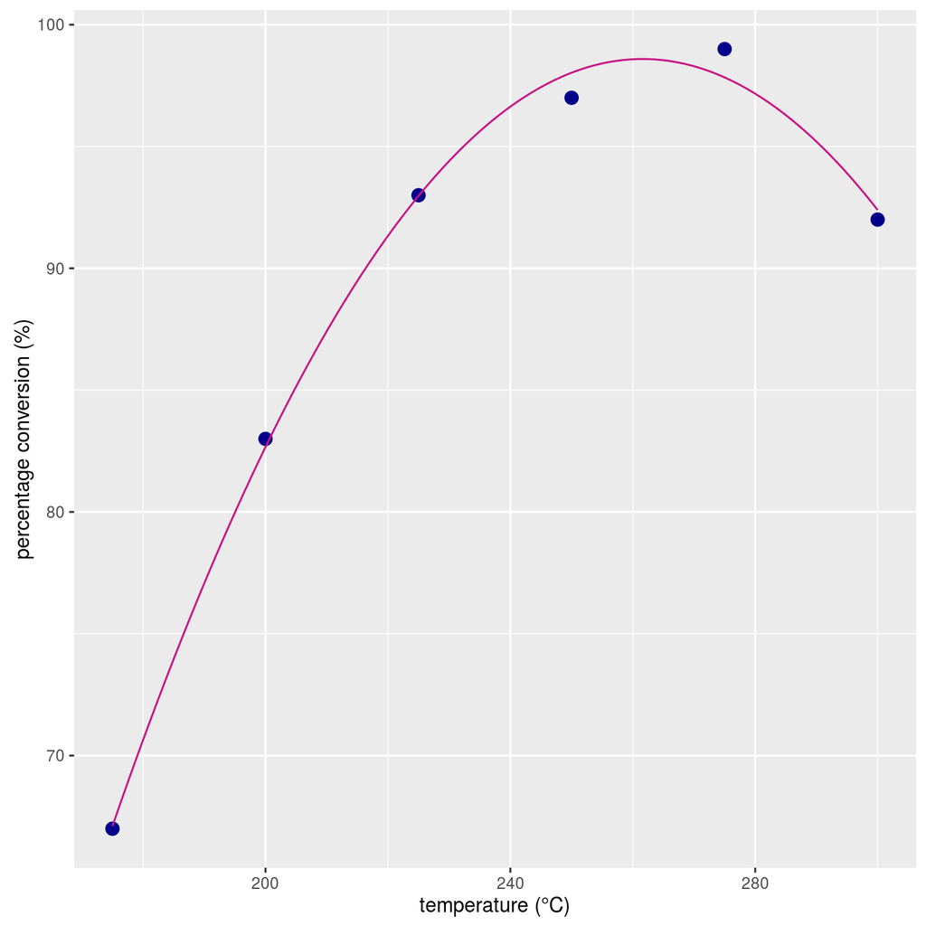

Plot of predition from quadratic model

```r
newdata <- data.frame(temperature = seq(min(polyester$temperature),
  max(max(polyester$temperature)), length = 100))
newdata$predict <- predict(fm, newdata = newdata)

ggp <- ggplot(data=polyester, mapping = aes(x=temperature, y=conversion)) +
  geom_point(colour="darkblue", size=3) +
  geom_line(data=newdata, mapping=aes(x=temperature, y=predict), colour="mediumvioletred") +
  xlab("temperature (°C)") + ylab("percentage conversion (%)")

print(ggp)
```